# Sex composition of infant filicide relative to homicide generally

ChoJin

2026-09-06

## Descriptive question

> How unusual is the sex composition of infant filicide relative to homicide generally?

This first analysis calculates three descriptive quantities for each group:

1. **Proportion female** among offender records with known sex: $F/(F+M)$.
2. **Female:male odds**: $F/M$.
3. **Odds ratio relative to general homicide**: $(F_{subtype}/M_{subtype})/(F_{general}/M_{general})$.

The analysis pools the latest ten complete FBI data years, 2016–2025, before calculating these quantities. Pooling the counts answers the question about the sex composition of the observed offender records across the period. It does not average the ten annual percentages.

## Analytic definitions

- The data are the FBI Supplementary Homicide Report (SHR) annual master files stored in `data/raw/fbi_shr/`.
- General homicide includes records coded murder or nonnegligent manslaughter. SHR circumstance codes 80 and 81, which identify justifiable homicide, are excluded.
- A filicide group requires a first-listed victim from birth through age 17 and a victim-to-offender relationship of son (`SO`), daughter (`DA`), stepson (`SS`), or stepdaughter (`SD`). Thus, parent and stepparent records are included. Infant filicide is the birth-through-364-day subset.
- The SHR age code `NB` means birth through 6 days; `BB` means 7 through 364 days. The combined infant category contains both. Numeric ages 01–17 are grouped as 1–4, 5–9, 10–14, and 15–17 years. The table also includes an all-filicide row covering birth through age 17.
- The analytic unit is a represented **offender record**, not an incident or a person tracked across incidents. An incident with multiple recorded offenders can contribute multiple offender records.
- Offender records coded male or female form the denominator for the requested sex-composition measures. Unknown and not-specified sex records are retained as a separate count but excluded from the proportion and odds calculations.
- In the SHR fixed-width layout, relationships are available for the first-listed victim only. Consequently, the filicide groups do not capture a child listed only as an additional victim in a multi-victim incident.

## Read and parse the FBI SHR files

The archive parsing code uses base R plus `knitr`, which is already used to render the document. The inferential section later uses `sandwich` for cluster-robust covariance estimation. No Python-generated analytic table is imported.

```r
analysis_start_year <- 2016L
analysis_end_year <- 2025L
analysis_years <- analysis_start_year:analysis_end_year

shr_directory <- file.path("data", "raw", "fbi_shr")
output_directory <- "output"
processed_data_directory <- file.path("data", "processed")
census_population_directory <- file.path("data", "raw", "census_population")
census_population_2010_2020_file <- file.path(
  census_population_directory,
  "nc-est2020-agesex-res.csv"
)
census_population_2020_2025_file <- file.path(
  census_population_directory,
  "nc-est2025-agesex-res.csv"
)
output_csv <- file.path(
  output_directory,
  sprintf(
    "homicide_subtype_sex_comparison_%d_%d.csv",
    analysis_start_year,
    analysis_end_year
  )
)

record_length <- 268L
maximum_additional_offenders_in_layout <- 10L
filicide_relationship_codes <- c("SO", "DA", "SS", "SD")
sex_levels <- c("male", "female", "unknown/not specified")
filicide_detailed_subtype_ids <- c(
  "filicide_birth_through_6_days",
  "filicide_days_7_through_364",
  "filicide_years_1_through_4",
  "filicide_years_5_through_9",
  "filicide_years_10_through_14",
  "filicide_years_15_through_17"
)
model_group_ids <- c("other_homicide", filicide_detailed_subtype_ids)
```

```r
read_shr_archive <- function(year, directory = shr_directory) {
  archive <- file.path(directory, sprintf("shr-%d.zip", year))
  if (!file.exists(archive)) {
    stop(
      sprintf(
        "Missing %s. The FBI SHR archive must be present before knitting.",
        archive
      )
    )
  }

  members <- utils::unzip(archive, list = TRUE)
  members <- members[!grepl("/$", members$Name), , drop = FALSE]
  if (nrow(members) != 1L) {
    stop(sprintf("Expected one data member in %s; found %d.", archive, nrow(members)))
  }

  connection <- unz(archive, members$Name[[1L]], open = "rt")
  on.exit(close(connection), add = TRUE)
  records <- readLines(connection, warn = FALSE, encoding = "latin1")

  # Legacy DAT files can end with a one-character DOS end-of-file record.
  records <- records[nchar(records, type = "chars") >= 90L]
  lengths <- nchar(records, type = "chars")
  if (any(lengths > record_length)) {
    stop(sprintf("At least one record in %s exceeds %d characters.", archive, record_length))
  }

  # Some official mid-2000s files physically omit trailing blank fields.
  # Right-padding restores the documented logical fixed-width layout.
  paste0(records, strrep(" ", record_length - lengths))
}

normalize_sex <- function(raw_code) {
  ifelse(
    raw_code == "M",
    "male",
    ifelse(raw_code == "F", "female", "unknown/not specified")
  )
}

classify_filicide_age <- function(raw_code) {
  if (raw_code == "NB") {
    return("filicide_birth_through_6_days")
  }
  if (raw_code == "BB") {
    return("filicide_days_7_through_364")
  }

  age <- suppressWarnings(as.integer(raw_code))
  if (is.na(age) || age < 1L || age > 17L) {
    return(NA_character_)
  }
  if (age <= 4L) {
    return("filicide_years_1_through_4")
  }
  if (age <= 9L) {
    return("filicide_years_5_through_9")
  }
  if (age <= 14L) {
    return("filicide_years_10_through_14")
  }
  "filicide_years_15_through_17"
}

extract_offender_segments <- function(record) {
  reported_additional <- suppressWarnings(as.integer(substr(record, 96L, 98L)))
  if (is.na(reported_additional)) {
    stop("Encountered an invalid additional-offender count.")
  }
  represented_additional <- min(
    reported_additional,
    maximum_additional_offenders_in_layout
  )

  segments <- substr(record, 81L, 92L)
  if (represented_additional > 0L) {
    starts <- 149L + (seq_len(represented_additional) - 1L) * 12L
    segments <- c(
      segments,
      vapply(starts, function(start) substr(record, start, start + 11L), character(1L))
    )
  }
  segments
}

empty_sex_counts <- function() {
  stats::setNames(integer(length(sex_levels)), sex_levels)
}

parse_shr_year <- function(year) {
  records <- read_shr_archive(year)
  # Position 71: A = murder and nonnegligent manslaughter.
  records <- records[substr(records, 71L, 71L) == "A"]

  general_counts <- empty_sex_counts()
  filicide_subtype_ids <- c(
    "filicide_under_18",
    "filicide_under_1_year",
    filicide_detailed_subtype_ids
  )
  filicide_counts <- stats::setNames(
    lapply(filicide_subtype_ids, function(subtype_id) empty_sex_counts()),
    filicide_subtype_ids
  )
  offender_record_chunks <- vector("list", length(records))

  for (record_index in seq_along(records)) {
    record <- records[[record_index]]
    segments <- extract_offender_segments(record)

    # Within a 12-character offender segment, positions 10-11 are the
    # circumstance. Codes 80/81 are justifiable homicide.
    circumstances <- substr(segments, 10L, 11L)
    segments <- segments[!circumstances %in% c("80", "81")]
    if (length(segments) == 0L) {
      next
    }

    offender_sex <- normalize_sex(substr(segments, 3L, 3L))
    general_counts <- general_counts + table(
      factor(offender_sex, levels = sex_levels)
    )

    first_victim_age <- substr(record, 76L, 77L)
    detailed_subtype_id <- classify_filicide_age(first_victim_age)
    # Within a 12-character offender segment, positions 8-9 are the
    # relationship of the first-listed victim to that offender.
    relationships <- substr(segments, 8L, 9L)
    qualifying <-
      !is.na(detailed_subtype_id) &
      relationships %in% filicide_relationship_codes

    homicide_group <- rep("other_homicide", length(segments))
    homicide_group[qualifying] <- detailed_subtype_id
    offender_record_chunks[[record_index]] <- data.frame(
      year = rep.int(year, length(segments)),
      source_record_id = sprintf("%d-%07d", year, record_index),
      homicide_group = homicide_group,
      offender_sex = offender_sex,
      stringsAsFactors = FALSE
    )

    if (any(qualifying)) {
      qualifying_sex <- offender_sex[qualifying]
      qualifying_counts <- table(factor(qualifying_sex, levels = sex_levels))
      filicide_counts[["filicide_under_18"]] <-
        filicide_counts[["filicide_under_18"]] + qualifying_counts
      filicide_counts[[detailed_subtype_id]] <-
        filicide_counts[[detailed_subtype_id]] + qualifying_counts

      if (detailed_subtype_id %in% filicide_detailed_subtype_ids[1:2]) {
        filicide_counts[["filicide_under_1_year"]] <-
          filicide_counts[["filicide_under_1_year"]] + qualifying_counts
      }
    }
  }

  list(
    counts = c(list(general_homicide = general_counts), filicide_counts),
    offender_records = do.call(rbind, offender_record_chunks)
  )
}
```

```r
annual_parsed_data <- lapply(analysis_years, parse_shr_year)
names(annual_parsed_data) <- analysis_years

annual_counts <- lapply(annual_parsed_data, function(year_data) year_data$counts)
offender_records <- do.call(
  rbind,
  lapply(annual_parsed_data, function(year_data) year_data$offender_records)
)
rownames(offender_records) <- NULL

subtype_ids <- names(annual_counts[[1L]])
pooled_counts <- lapply(
  subtype_ids,
  function(subtype_id) {
    Reduce(
      `+`,
      lapply(annual_counts, function(year_data) year_data[[subtype_id]])
    )
  }
)
names(pooled_counts) <- subtype_ids

# Internal consistency checks: the detailed groups must sum exactly to their
# two combined categories.
stopifnot(
  nrow(offender_records) == sum(pooled_counts$general_homicide),
  all(offender_records$homicide_group %in% model_group_ids),
  all(
    pooled_counts$filicide_under_1_year ==
      pooled_counts$filicide_birth_through_6_days +
        pooled_counts$filicide_days_7_through_364
  ),
  all(
    pooled_counts$filicide_under_18 ==
      Reduce(`+`, pooled_counts[filicide_detailed_subtype_ids])
  )
)
```

## Compute the descriptive comparison

```r
subtype_labels <- c(
  general_homicide = "General homicide (reference)",
  filicide_under_18 = "Filicide, birth-17 years",
  filicide_under_1_year = "Infant filicide, birth-364 days",
  filicide_birth_through_6_days = "Filicide, birth-6 days",
  filicide_days_7_through_364 = "Infant filicide, 7-364 days",
  filicide_years_1_through_4 = "Filicide, 1-4 years",
  filicide_years_5_through_9 = "Filicide, 5-9 years",
  filicide_years_10_through_14 = "Filicide, 10-14 years",
  filicide_years_15_through_17 = "Filicide, 15-17 years"
)

comparison <- data.frame(
  analysis_start_year = analysis_start_year,
  analysis_end_year = analysis_end_year,
  homicide_subtype = unname(subtype_labels[subtype_ids]),
  male_offender_records = vapply(
    pooled_counts,
    function(counts) unname(counts[["male"]]),
    integer(1L)
  ),
  female_offender_records = vapply(
    pooled_counts,
    function(counts) unname(counts[["female"]]),
    integer(1L)
  ),
  unknown_or_not_specified_offender_records = vapply(
    pooled_counts,
    function(counts) unname(counts[["unknown/not specified"]]),
    integer(1L)
  )
)

comparison$known_sex_offender_records <-
  comparison$male_offender_records + comparison$female_offender_records
comparison$total_offender_records <-
  comparison$known_sex_offender_records +
  comparison$unknown_or_not_specified_offender_records
comparison$female_proportion_known_sex <-
  comparison$female_offender_records / comparison$known_sex_offender_records
comparison$female_to_male_odds <-
  comparison$female_offender_records / comparison$male_offender_records

general_homicide_odds <- comparison$female_to_male_odds[
  subtype_ids == "general_homicide"
]
comparison$odds_ratio_vs_general_homicide <-
  comparison$female_to_male_odds / general_homicide_odds

stopifnot(
  nrow(comparison) == length(subtype_labels),
  length(general_homicide_odds) == 1L,
  comparison$odds_ratio_vs_general_homicide[[1L]] == 1
)

female_proportion_by_subtype <- stats::setNames(
  comparison$female_proportion_known_sex,
  subtype_ids
)
female_to_male_odds_by_subtype <- stats::setNames(
  comparison$female_to_male_odds,
  subtype_ids
)
odds_ratio_by_subtype <- stats::setNames(
  comparison$odds_ratio_vs_general_homicide,
  subtype_ids
)

dir.create(output_directory, recursive = TRUE, showWarnings = FALSE)
utils::write.csv(comparison, output_csv, row.names = FALSE, na = "")
```

Offender-sex composition in FBI SHR records, 2016-2025

| Homicide subtype | Male | Female | Unknown / not specified | Female proportion | Female:male odds | OR vs. general homicide |
| --- | --- | --- | --- | --- | --- | --- |
| General homicide (reference) | 132,226 | 18,298 | 49,125 | 12.2% | 0.138 | 1.000 |
| Filicide, birth-17 years | 1,740 | 1,692 | 9 | 49.3% | 0.972 | 7.027 |
| Infant filicide, birth-364 days | 715 | 514 | 1 | 41.8% | 0.719 | 5.195 |
| Filicide, birth-6 days | 31 | 61 | 0 | 66.3% | 1.968 | 14.219 |
| Infant filicide, 7-364 days | 684 | 453 | 1 | 39.8% | 0.662 | 4.786 |
| Filicide, 1-4 years | 592 | 733 | 5 | 55.3% | 1.238 | 8.947 |
| Filicide, 5-9 years | 212 | 265 | 1 | 55.6% | 1.250 | 9.033 |
| Filicide, 10-14 years | 151 | 135 | 0 | 47.2% | 0.894 | 6.461 |
| Filicide, 15-17 years | 70 | 45 | 2 | 39.1% | 0.643 | 4.645 |

## Descriptive result

Across 2016–2025, the female proportion among general-homicide offender records with known sex was 12.2%. For infant filicide as a whole, it was 41.8%. The corresponding female:male odds were 0.138 and 0.719, respectively. Thus, the female:male odds in recorded infant filicide were 5.19 times the female:male odds in homicide generally.

The infant period is not compositionally uniform. The odds ratio was 14.22 for filicide during the first 6 days after birth and 4.79 for days 7–364. These are descriptive comparisons of reported offender records, not causal estimates and not statements about any individual case.

The unrounded table is written during knitting to output/homicide_subtype_sex_comparison_2016_2025.csv.

## Inferential model preparation

Formal comparisons require mutually exclusive groups. The inferential data therefore use the six detailed filicide age groups and a reference group of all other homicide offender records. The reference excludes every offender record assigned to one of the six filicide groups. The combined birth–364-day and birth–17-year rows remain descriptive rollups and are not entered as additional model observations.

The outcome is female versus male among records with known sex. Unknown or not-specified sex is analyzed separately as missing outcome information. Each source-record identifier groups offender segments represented on the same SHR fixed-width record; cluster-robust inference below allows those segments to be correlated.

```r
model_input_csv <- file.path(
  output_directory,
  sprintf(
    "inferential_model_input_%d_%d.csv",
    analysis_start_year,
    analysis_end_year
  )
)
model_results_csv <- file.path(
  output_directory,
  sprintf(
    "inferential_model_results_%d_%d.csv",
    analysis_start_year,
    analysis_end_year
  )
)
model_diagnostics_csv <- file.path(
  output_directory,
  sprintf(
    "inferential_model_diagnostics_%d_%d.csv",
    analysis_start_year,
    analysis_end_year
  )
)
cell_diagnostics_csv <- file.path(
  output_directory,
  sprintf(
    "inferential_model_cell_diagnostics_%d_%d.csv",
    analysis_start_year,
    analysis_end_year
  )
)
missingness_csv <- file.path(
  output_directory,
  sprintf(
    "inferential_model_missingness_%d_%d.csv",
    analysis_start_year,
    analysis_end_year
  )
)
period_sensitivity_csv <- file.path(
  output_directory,
  sprintf(
    "inferential_model_period_sensitivity_%d_%d.csv",
    analysis_start_year,
    analysis_end_year
  )
)
leave_one_year_out_csv <- file.path(
  output_directory,
  sprintf(
    "inferential_model_leave_one_year_out_%d_%d.csv",
    analysis_start_year,
    analysis_end_year
  )
)

model_group_labels <- c(
  other_homicide = "All other homicide (reference)",
  subtype_labels[filicide_detailed_subtype_ids]
)

offender_records$homicide_group <- factor(
  offender_records$homicide_group,
  levels = model_group_ids
)
offender_records$offender_sex <- factor(
  offender_records$offender_sex,
  levels = sex_levels
)

count_array <- table(
  year = factor(offender_records$year, levels = analysis_years),
  homicide_group = offender_records$homicide_group,
  offender_sex = offender_records$offender_sex
)

# expand.grid varies its first factor fastest, matching the vectorized first
# dimension of each year-by-group slice in count_array.
annual_model_counts <- expand.grid(
  year = analysis_years,
  homicide_group = model_group_ids,
  KEEP.OUT.ATTRS = FALSE,
  stringsAsFactors = FALSE
)
annual_model_counts$homicide_group_label <- unname(
  model_group_labels[annual_model_counts$homicide_group]
)
annual_model_counts$male_offender_records <- as.integer(
  count_array[, , "male"]
)
annual_model_counts$female_offender_records <- as.integer(
  count_array[, , "female"]
)
annual_model_counts$unknown_or_not_specified_offender_records <- as.integer(
  count_array[, , "unknown/not specified"]
)
annual_model_counts$known_sex_offender_records <-
  annual_model_counts$male_offender_records +
  annual_model_counts$female_offender_records
annual_model_counts$total_offender_records <-
  annual_model_counts$known_sex_offender_records +
  annual_model_counts$unknown_or_not_specified_offender_records
annual_model_counts$female_proportion_known_sex <- with(
  annual_model_counts,
  female_offender_records / known_sex_offender_records
)
annual_model_counts$unknown_proportion_all_records <- with(
  annual_model_counts,
  unknown_or_not_specified_offender_records / total_offender_records
)

stopifnot(
  sum(annual_model_counts$total_offender_records) == nrow(offender_records),
  all(annual_model_counts$known_sex_offender_records > 0L)
)

utils::write.csv(annual_model_counts, model_input_csv, row.names = FALSE, na = "")
```

## Primary year-adjusted model

The primary model is a binary logistic regression with categorical homicide group and categorical data year. Age is deliberately categorical because the age intervals have unequal widths and the two infant codes are qualitatively distinct. Standard errors are clustered by SHR source record.

```r
if (!requireNamespace("sandwich", quietly = TRUE)) {
  stop(
    paste(
      "The inferential section requires the sandwich package.",
      "Install it with install.packages('sandwich') and knit again."
    )
  )
}

known_sex_records <- offender_records[
  offender_records$offender_sex %in% c("male", "female"),
  ,
  drop = FALSE
]
known_sex_records$homicide_group <- factor(
  known_sex_records$homicide_group,
  levels = model_group_ids
)
known_sex_records$is_female <- as.integer(
  known_sex_records$offender_sex == "female"
)
known_sex_records$year_factor <- factor(known_sex_records$year)

primary_model <- stats::glm(
  is_female ~ homicide_group + year_factor,
  family = stats::binomial(),
  data = known_sex_records
)
primary_cluster_vcov <- sandwich::vcovCL(
  primary_model,
  cluster = known_sex_records$source_record_id,
  type = "HC1"
)

robust_wald_test <- function(model, covariance, coefficient_names) {
  beta <- stats::coef(model)[coefficient_names]
  covariance_subset <- covariance[
    coefficient_names,
    coefficient_names,
    drop = FALSE
  ]
  statistic <- drop(crossprod(beta, solve(covariance_subset, beta)))
  degrees_of_freedom <- length(beta)
  c(
    statistic = statistic,
    degrees_of_freedom = degrees_of_freedom,
    p_value = stats::pchisq(
      statistic,
      df = degrees_of_freedom,
      lower.tail = FALSE
    )
  )
}

group_coefficient_names <- paste0(
  "homicide_group",
  filicide_detailed_subtype_ids
)
stopifnot(
  primary_model$converged,
  all(group_coefficient_names %in% names(stats::coef(primary_model)))
)

omnibus_group_test <- robust_wald_test(
  primary_model,
  primary_cluster_vcov,
  group_coefficient_names
)

group_beta <- stats::coef(primary_model)[group_coefficient_names]
group_standard_error <- sqrt(diag(primary_cluster_vcov))[group_coefficient_names]
group_z <- group_beta / group_standard_error
group_p <- 2 * stats::pnorm(abs(group_z), lower.tail = FALSE)

pooled_model_counts <- data.frame(
  homicide_group = model_group_ids,
  homicide_group_label = unname(model_group_labels[model_group_ids]),
  male_offender_records = colSums(count_array[, , "male"]),
  female_offender_records = colSums(count_array[, , "female"]),
  unknown_or_not_specified_offender_records = colSums(
    count_array[, , "unknown/not specified"]
  ),
  row.names = NULL,
  check.names = FALSE
)
pooled_model_counts$known_sex_offender_records <- with(
  pooled_model_counts,
  male_offender_records + female_offender_records
)
pooled_model_counts$total_offender_records <- with(
  pooled_model_counts,
  known_sex_offender_records + unknown_or_not_specified_offender_records
)
pooled_model_counts$female_proportion_known_sex <- with(
  pooled_model_counts,
  female_offender_records / known_sex_offender_records
)
pooled_model_counts$female_to_male_odds <- with(
  pooled_model_counts,
  female_offender_records / male_offender_records
)

wilson_interval <- function(successes, trials, confidence_level = 0.95) {
  z <- stats::qnorm(1 - (1 - confidence_level) / 2)
  proportion <- successes / trials
  denominator <- 1 + z^2 / trials
  center <- (proportion + z^2 / (2 * trials)) / denominator
  half_width <- z * sqrt(
    proportion * (1 - proportion) / trials + z^2 / (4 * trials^2)
  ) / denominator
  c(lower = center - half_width, upper = center + half_width)
}

proportion_intervals <- t(vapply(
  seq_len(nrow(pooled_model_counts)),
  function(row_number) {
    wilson_interval(
      pooled_model_counts$female_offender_records[[ row_number]],
      pooled_model_counts$known_sex_offender_records[[ row_number]]
    )
  },
  numeric(2L)
))

inferential_results <- pooled_model_counts
inferential_results$female_proportion_ci_lower <- proportion_intervals[, "lower"]
inferential_results$female_proportion_ci_upper <- proportion_intervals[, "upper"]
inferential_results$adjusted_odds_ratio_vs_other_homicide <- c(
  1,
  exp(unname(group_beta))
)
inferential_results$cluster_robust_ci_lower <- c(
  1,
  exp(unname(group_beta - stats::qnorm(0.975) * group_standard_error))
)
inferential_results$cluster_robust_ci_upper <- c(
  1,
  exp(unname(group_beta + stats::qnorm(0.975) * group_standard_error))
)
inferential_results$p_value <- c(NA_real_, unname(group_p))
inferential_results$holm_adjusted_p_value <- c(
  NA_real_,
  stats::p.adjust(unname(group_p), method = "holm")
)

utils::write.csv(inferential_results, model_results_csv, row.names = FALSE, na = "")
```

Year-adjusted female-offender odds by mutually exclusive homicide group, 2016-2025

| Group | Male | Female | Female proportion (95% Wilson CI) | Adjusted OR (95% cluster-robust CI) | Holm-adjusted p |
| --- | --- | --- | --- | --- | --- |
| All other homicide (reference) | 130,486 | 16,606 | 11.3% (11.1%, 11.5%) | 1.000 (reference) | – |
| Filicide, birth-6 days | 31 | 61 | 66.3% (56.2%, 75.1%) | 15.803 (10.930, 22.849) | <0.001 |
| Infant filicide, 7-364 days | 684 | 453 | 39.8% (37.0%, 42.7%) | 5.233 (4.738, 5.781) | <0.001 |
| Filicide, 1-4 years | 592 | 733 | 55.3% (52.6%, 58.0%) | 9.756 (8.879, 10.719) | <0.001 |
| Filicide, 5-9 years | 212 | 265 | 55.6% (51.1%, 60.0%) | 9.830 (8.371, 11.542) | <0.001 |
| Filicide, 10-14 years | 151 | 135 | 47.2% (41.5%, 53.0%) | 7.028 (5.714, 8.645) | <0.001 |
| Filicide, 15-17 years | 70 | 45 | 39.1% (30.7%, 48.3%) | 5.070 (3.568, 7.204) | <0.001 |

The cluster-robust omnibus Wald test of the six homicide-group coefficients is $\chi^2(6) =$ 4460.70, $p$ <0.001. This tests whether the recorded female:male odds in at least one detailed filicide group differ from the odds among all other homicide records after adjustment for data year.

## Suitability checks and model diagnostics

```r
# A grouped version of the same main-effects model supports cell-level
# residual, goodness-of-fit, overdispersion, and influence diagnostics.
annual_model_counts$homicide_group_factor <- factor(
  annual_model_counts$homicide_group,
  levels = model_group_ids
)
annual_model_counts$year_factor <- factor(annual_model_counts$year)
grouped_model <- stats::glm(
  cbind(female_offender_records, male_offender_records) ~
    homicide_group_factor + year_factor,
  family = stats::binomial(),
  data = annual_model_counts
)

pearson_chisq <- sum(stats::residuals(grouped_model, type = "pearson")^2)
pearson_degrees_of_freedom <- stats::df.residual(grouped_model)
pearson_dispersion <- pearson_chisq / pearson_degrees_of_freedom
pearson_gof_p <- stats::pchisq(
  pearson_chisq,
  df = pearson_degrees_of_freedom,
  lower.tail = FALSE
)

cell_diagnostics <- annual_model_counts[c(
  "year",
  "homicide_group",
  "homicide_group_label",
  "male_offender_records",
  "female_offender_records",
  "known_sex_offender_records"
)]
cell_diagnostics$fitted_female_proportion <- stats::fitted(grouped_model)
cell_diagnostics$pearson_residual <- stats::residuals(
  grouped_model,
  type = "pearson"
)
cell_diagnostics$standardized_pearson_residual <- stats::rstandard(
  grouped_model,
  type = "pearson"
)
cell_diagnostics$leverage <- stats::hatvalues(grouped_model)
cell_diagnostics$cooks_distance <- stats::cooks.distance(grouped_model)
influence_threshold <- 4 / nrow(cell_diagnostics)
cell_diagnostics$flag_cooks_distance <-
  cell_diagnostics$cooks_distance > influence_threshold

# Check whether the filicide/general contrast differs across the reporting
# transition by testing all group-by-period interactions jointly.
known_sex_records$transition_period <- factor(
  ifelse(known_sex_records$year <= 2020L, "2016-2020", "2021-2025"),
  levels = c("2016-2020", "2021-2025")
)
transition_model <- stats::glm(
  is_female ~ homicide_group * transition_period,
  family = stats::binomial(),
  data = known_sex_records
)
transition_cluster_vcov <- sandwich::vcovCL(
  transition_model,
  cluster = known_sex_records$source_record_id,
  type = "HC1"
)
transition_interaction_names <- grep(
  "^homicide_group.*:transition_period",
  names(stats::coef(transition_model)),
  value = TRUE
)
transition_interaction_test <- robust_wald_test(
  transition_model,
  transition_cluster_vcov,
  transition_interaction_names
)

estimate_period_specific_odds_ratios <- function(period_label, period_years) {
  period_records <- known_sex_records[
    known_sex_records$year %in% period_years,
    ,
    drop = FALSE
  ]
  period_records$homicide_group <- factor(
    period_records$homicide_group,
    levels = model_group_ids
  )
  period_records$year_factor <- factor(period_records$year)

  period_model <- stats::glm(
    is_female ~ homicide_group + year_factor,
    family = stats::binomial(),
    data = period_records
  )
  period_vcov <- sandwich::vcovCL(
    period_model,
    cluster = period_records$source_record_id,
    type = "HC1"
  )
  coefficient_names <- paste0(
    "homicide_group",
    filicide_detailed_subtype_ids
  )
  beta <- stats::coef(period_model)[coefficient_names]
  standard_error <- sqrt(diag(period_vcov))[coefficient_names]
  p_value <- 2 * stats::pnorm(
    abs(beta / standard_error),
    lower.tail = FALSE
  )

  data.frame(
    period = period_label,
    start_year = min(period_years),
    end_year = max(period_years),
    homicide_group = filicide_detailed_subtype_ids,
    homicide_group_label = unname(
      model_group_labels[filicide_detailed_subtype_ids]
    ),
    adjusted_odds_ratio_vs_other_homicide = exp(unname(beta)),
    cluster_robust_ci_lower = exp(
      unname(beta - stats::qnorm(0.975) * standard_error)
    ),
    cluster_robust_ci_upper = exp(
      unname(beta + stats::qnorm(0.975) * standard_error)
    ),
    p_value = unname(p_value),
    holm_adjusted_p_value = stats::p.adjust(
      unname(p_value),
      method = "holm"
    ),
    stringsAsFactors = FALSE
  )
}

period_specific_results <- rbind(
  estimate_period_specific_odds_ratios("2016-2020", 2016:2020),
  estimate_period_specific_odds_ratios("2021-2025", 2021:2025)
)

# Cook's distance is strongly affected by the much larger reference cells.
# Leave-one-year-out estimates provide a direct influence sensitivity check.
grouped_group_coefficient_names <- paste0(
  "homicide_group_factor",
  filicide_detailed_subtype_ids
)
full_grouped_odds_ratios <- exp(
  stats::coef(grouped_model)[grouped_group_coefficient_names]
)
leave_one_year_out_results <- do.call(
  rbind,
  lapply(analysis_years, function(omitted_year) {
    reduced_data <- annual_model_counts[
      annual_model_counts$year != omitted_year,
      ,
      drop = FALSE
    ]
    reduced_data$year_factor <- factor(reduced_data$year)
    reduced_model <- stats::glm(
      cbind(female_offender_records, male_offender_records) ~
        homicide_group_factor + year_factor,
      family = stats::binomial(),
      data = reduced_data
    )
    reduced_odds_ratios <- exp(
      stats::coef(reduced_model)[grouped_group_coefficient_names]
    )
    data.frame(
      omitted_year = omitted_year,
      homicide_group = filicide_detailed_subtype_ids,
      homicide_group_label = unname(
        model_group_labels[filicide_detailed_subtype_ids]
      ),
      full_model_adjusted_odds_ratio = unname(full_grouped_odds_ratios),
      leave_one_year_out_adjusted_odds_ratio = unname(reduced_odds_ratios),
      percent_change_from_full_model = 100 * unname(
        reduced_odds_ratios / full_grouped_odds_ratios - 1
      ),
      stringsAsFactors = FALSE
    )
  })
)
maximum_leave_one_year_out_change <- max(
  abs(leave_one_year_out_results$percent_change_from_full_model)
)

# Missing sex is not treated as a third substantive outcome. Its pattern and
# worst-case female-proportion bounds are reported separately.
missingness_results <- pooled_model_counts[c(
  "homicide_group",
  "homicide_group_label",
  "male_offender_records",
  "female_offender_records",
  "unknown_or_not_specified_offender_records",
  "known_sex_offender_records",
  "total_offender_records"
)]
missingness_results$unknown_proportion_all_records <- with(
  missingness_results,
  unknown_or_not_specified_offender_records / total_offender_records
)
missingness_results$female_proportion_lower_bound <- with(
  missingness_results,
  female_offender_records / total_offender_records
)
missingness_results$female_proportion_upper_bound <- with(
  missingness_results,
  (female_offender_records + unknown_or_not_specified_offender_records) /
    total_offender_records
)

knownness_table <- with(
  missingness_results,
  cbind(
    known_sex = known_sex_offender_records,
    unknown_or_not_specified = unknown_or_not_specified_offender_records
  )
)
knownness_test <- suppressWarnings(stats::chisq.test(
  knownness_table,
  correct = FALSE
))

zero_annual_known_sex_cells <- sum(
  annual_model_counts$male_offender_records == 0L |
    annual_model_counts$female_offender_records == 0L
)

model_diagnostics <- data.frame(
  diagnostic = c(
    "Primary logistic model converged (1=yes)",
    "Known-sex offender records in primary model",
    "SHR source-record clusters",
    "Annual group cells with zero male or zero female records",
    "Pearson overdispersion ratio",
    "Grouped-model Pearson goodness-of-fit",
    "Cells above Cook's-distance screening threshold",
    "Maximum Cook's distance",
    "Maximum absolute OR change in leave-one-year-out analysis (%)",
    "Robust omnibus homicide-group Wald test",
    "Robust group-by-transition-period Wald test",
    "Known-versus-unknown sex Pearson test",
    "Minimum expected count in knownness test"
  ),
  estimate = c(
    as.numeric(primary_model$converged),
    nrow(known_sex_records),
    length(unique(known_sex_records$source_record_id)),
    zero_annual_known_sex_cells,
    pearson_dispersion,
    pearson_chisq,
    sum(cell_diagnostics$flag_cooks_distance),
    max(cell_diagnostics$cooks_distance),
    maximum_leave_one_year_out_change,
    omnibus_group_test[["statistic"]],
    transition_interaction_test[["statistic"]],
    unname(knownness_test$statistic),
    min(knownness_test$expected)
  ),
  degrees_of_freedom = c(
    NA,
    NA,
    NA,
    NA,
    pearson_degrees_of_freedom,
    pearson_degrees_of_freedom,
    NA,
    NA,
    NA,
    omnibus_group_test[["degrees_of_freedom"]],
    transition_interaction_test[["degrees_of_freedom"]],
    unname(knownness_test$parameter),
    NA
  ),
  p_value = c(
    NA,
    NA,
    NA,
    NA,
    NA,
    pearson_gof_p,
    NA,
    NA,
    NA,
    omnibus_group_test[["p_value"]],
    transition_interaction_test[["p_value"]],
    knownness_test$p.value,
    NA
  ),
  stringsAsFactors = FALSE
)

utils::write.csv(model_diagnostics, model_diagnostics_csv, row.names = FALSE, na = "")
utils::write.csv(cell_diagnostics, cell_diagnostics_csv, row.names = FALSE, na = "")
utils::write.csv(missingness_results, missingness_csv, row.names = FALSE, na = "")
utils::write.csv(
  period_specific_results,
  period_sensitivity_csv,
  row.names = FALSE,
  na = ""
)
utils::write.csv(
  leave_one_year_out_results,
  leave_one_year_out_csv,
  row.names = FALSE,
  na = ""
)
```

The group-by-period test is statistically significant when its $p$-value is below the chosen threshold. In that event, the pooled model should be described as a ten-year average and the following period-specific estimates should be reported as a sensitivity analysis.

Sensitivity estimates before and after the 2021 reporting transition

| Period | Group | Adjusted OR (95% cluster-robust CI) |
| --- | --- | --- |
| 2016-2020 | Filicide, birth-6 days | 16.59 (10.61, 25.93) |
| 2016-2020 | Infant filicide, 7-364 days | 4.49 (3.87, 5.21) |
| 2016-2020 | Filicide, 1-4 years | 8.88 (7.76, 10.16) |
| 2016-2020 | Filicide, 5-9 years | 8.36 (6.60, 10.59) |
| 2016-2020 | Filicide, 10-14 years | 5.80 (4.23, 7.94) |
| 2016-2020 | Filicide, 15-17 years | 6.01 (3.41, 10.58) |
| 2021-2025 | Filicide, birth-6 days | 14.00 (7.29, 26.89) |
| 2021-2025 | Infant filicide, 7-364 days | 6.02 (5.26, 6.89) |
| 2021-2025 | Filicide, 1-4 years | 10.74 (9.42, 12.25) |
| 2021-2025 | Filicide, 5-9 years | 11.25 (9.03, 14.02) |
| 2021-2025 | Filicide, 10-14 years | 8.20 (6.21, 10.83) |
| 2021-2025 | Filicide, 15-17 years | 4.59 (2.93, 7.19) |

Pre-specified model checks

| Diagnostic | Result |
| --- | --- |
| Primary model converged | Yes |
| Annual cells with a zero male or female count | 0 |
| Pearson overdispersion ratio | 0.895 |
| Pearson goodness-of-fit p | 0.691 |
| Cells above Cook’s-distance screen | 10 |
| Largest absolute leave-one-year-out OR change | 16.3% |
| Age group x 2021 transition p | 0.00616 |
| Known vs. unknown sex p | <0.001 |

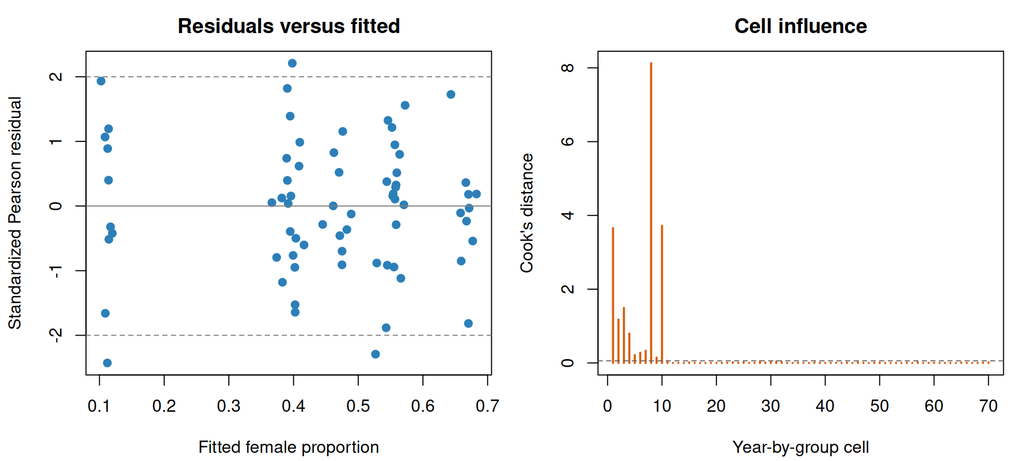

A normal Q–Q plot and a Shapiro–Wilk normality test are intentionally not used. A binomial logistic model does not assume normally distributed outcomes or normally distributed residuals. The relevant diagnostics are sparse cells, convergence or separation, extra-binomial variation, influence, temporal heterogeneity, and dependence among offender records.

The annual disjoint input, inferential estimates, model diagnostics, cell-level diagnostics, and missingness sensitivity table are written to the `output/` directory during knitting.

## Population-denominated comparison

The homicide-composition comparison above does not estimate how often women or men in the parent population commit filicide. For that question, the relevant denominator is exposure as a parent. The closest annual national series is the U.S. Census Bureau’s count of mothers and fathers with at least one coresident, never-married biological, step, or adopted child under 18.

The code below uses the published CPS ASEC historical workbook for 2016–2023. Because the published historical table currently ends in 2023, it applies the same parent-pointer definition to the 2024 and 2025 CPS ASEC public-use microdata. It also reproduces 2023 from microdata as a validation check. The large public-use files are downloaded from Census only when they are absent from the local cache.

This is a useful but imperfect denominator. It excludes nonresident parents, whereas SHR does not report whether an offender lived with the victim. It is national rather than limited to SHR-reporting jurisdictions, and SHR is an incomplete reporting system. Consequently, the quantities below are **reported offender-record rates per national coresident parent-year**, not complete U.S. incidence rates or individual probabilities.

```r
if (!requireNamespace("readxl", quietly = TRUE)) {
  stop(
    paste(
      "The population-denominator section requires the readxl package.",
      "Install it with install.packages('readxl') and knit again."
    )
  )
}

parent_denominator_directory <- file.path(
  "data",
  "raw",
  "census_parent_denominators"
)
dir.create(parent_denominator_directory, recursive = TRUE, showWarnings = FALSE)

census_historical_parent_url <- paste0(
  "https://www2.census.gov/programs-surveys/demo/tables/families/",
  "time-series/adults/ad2.xls"
)
census_historical_parent_file <- file.path(
  parent_denominator_directory,
  "ad2.xls"
)

download_if_missing <- function(url, destination) {
  if (file.exists(destination) && file.info(destination)$size > 0) {
    return(invisible(destination))
  }

  temporary_destination <- tempfile(
    pattern = paste0(basename(destination), "-"),
    tmpdir = dirname(destination)
  )
  on.exit(unlink(temporary_destination), add = TRUE)
  utils::download.file(
    url,
    temporary_destination,
    mode = "wb",
    quiet = FALSE
  )
  if (!file.rename(temporary_destination, destination)) {
    stop(sprintf("Could not move the downloaded file to %s.", destination))
  }
  invisible(destination)
}

download_if_missing(
  census_historical_parent_url,
  census_historical_parent_file
)

extract_published_parent_section <- function(raw_table, heading, sex_label) {
  labels <- as.character(raw_table[[1L]])
  section_start <- which(labels == heading)[[1L]] + 1L
  following_blank <- which(
    is.na(labels[section_start:length(labels)]) |
      !nzchar(labels[section_start:length(labels)])
  )[[1L]]
  section_end <- section_start + following_blank - 2L

  section <- raw_table[section_start:section_end, c(1L, 2L)]
  names(section) <- c("year_label", "parent_count_thousands")
  section$year <- suppressWarnings(
    as.integer(sub("^\\.\\.(\\d{4}).*$", "\\1", section$year_label))
  )
  section$parent_count <-
    as.numeric(section$parent_count_thousands) * 1000
  section$sex <- sex_label

  section <- section[!is.na(section$year), , drop = FALSE]
  # Revised rows (for example, 2021r) precede the original row in the file.
  section <- section[!duplicated(section$year), , drop = FALSE]
  section[, c("year", "sex", "parent_count")]
}

published_parent_raw <- readxl::read_excel(
  census_historical_parent_file,
  sheet = "Table AD-2",
  col_names = FALSE
)
published_parent_denominators <- rbind(
  extract_published_parent_section(
    published_parent_raw,
    ".Coresident mothers",
    "female"
  ),
  extract_published_parent_section(
    published_parent_raw,
    ".Coresident fathers",
    "male"
  )
)
published_parent_denominators <- published_parent_denominators[
  published_parent_denominators$year %in% 2016:2023,
  ,
  drop = FALSE
]

parse_cps_asec_parent_denominators <- function(year, directory) {
  source_url <- sprintf(
    paste0(
      "https://www2.census.gov/programs-surveys/cps/datasets/%d/march/",
      "asec%d_pubuse.dat.gz"
    ),
    year,
    year
  )
  source_file <- file.path(
    directory,
    sprintf("asec%d_pubuse.dat.gz", year)
  )
  download_if_missing(source_url, source_file)

  connection <- gzfile(source_file, open = "rt")
  on.exit(close(connection), add = TRUE)
  records <- readLines(connection, warn = FALSE)
  records <- records[substr(records, 1L, 1L) == "3"]

  fixed_numeric <- function(start, stop) {
    suppressWarnings(as.numeric(substr(records, start, stop)))
  }

  people <- data.frame(
    household_sequence = substr(records, 36L, 40L),
    line_number = fixed_numeric(2L, 3L),
    parent_1_line = fixed_numeric(51L, 52L),
    parent_2_line = fixed_numeric(53L, 54L),
    supplement_weight = fixed_numeric(71L, 78L) / 100,
    age = fixed_numeric(79L, 80L),
    marital_status = fixed_numeric(90L, 90L),
    sex_code = fixed_numeric(92L, 92L),
    parent_1_type = fixed_numeric(141L, 142L),
    parent_2_type = fixed_numeric(143L, 144L),
    stringsAsFactors = FALSE
  )
  rm(records)

  person_key <- paste(
    people$household_sequence,
    people$line_number,
    sep = "-"
  )
  if (anyDuplicated(person_key)) {
    stop(sprintf("Person keys are not unique in the %d CPS ASEC file.", year))
  }

  # Table AD-2 defines children as never-married biological, step, or adopted
  # children. PEPAR1TYP/PEPAR2TYP codes 1:3 represent those three types.
  eligible_child <- people$age < 18L & people$marital_status == 7L
  parent_1_present <-
    eligible_child &
    people$parent_1_line > 0L &
    people$parent_1_type %in% 1:3
  parent_2_present <-
    eligible_child &
    people$parent_2_line > 0L &
    people$parent_2_type %in% 1:3

  referenced_parent_keys <- unique(c(
    paste(
      people$household_sequence[parent_1_present],
      people$parent_1_line[parent_1_present],
      sep = "-"
    ),
    paste(
      people$household_sequence[parent_2_present],
      people$parent_2_line[parent_2_present],
      sep = "-"
    )
  ))
  is_coresident_parent <- person_key %in% referenced_parent_keys

  parent_records <- people[
    is_coresident_parent & people$sex_code %in% c(1L, 2L),
    ,
    drop = FALSE
  ]
  totals <- stats::aggregate(
    supplement_weight ~ sex_code,
    data = parent_records,
    FUN = sum
  )
  names(totals)[names(totals) == "supplement_weight"] <- "parent_count"
  totals$sex <- ifelse(totals$sex_code == 1L, "male", "female")
  totals$year <- year
  totals$source_url <- source_url
  totals$source_file_md5 <- unname(tools::md5sum(source_file))
  totals[, c(
    "year",
    "sex",
    "parent_count",
    "source_url",
    "source_file_md5"
  )]
}

# The 2023 reconstruction validates the algorithm against the final published
# historical table. The same algorithm supplies 2024 and 2025.
microdata_parent_denominators <- do.call(
  rbind,
  lapply(2023:2025, parse_cps_asec_parent_denominators,
         directory = parent_denominator_directory)
)

parent_denominator_validation <- merge(
  published_parent_denominators[
    published_parent_denominators$year == 2023L,
    ,
    drop = FALSE
  ],
  microdata_parent_denominators[
    microdata_parent_denominators$year == 2023L,
    c("year", "sex", "parent_count"),
    drop = FALSE
  ],
  by = c("year", "sex"),
  suffixes = c("_published", "_reconstructed")
)
parent_denominator_validation$relative_difference <- with(
  parent_denominator_validation,
  (parent_count_reconstructed - parent_count_published) /
    parent_count_published
)
stopifnot(
  nrow(parent_denominator_validation) == 2L,
  max(abs(parent_denominator_validation$relative_difference)) < 0.001
)

published_parent_denominators$source_method <-
  "Published Census CPS ASEC historical Table AD-2"
published_parent_denominators$source_url <- census_historical_parent_url
published_parent_denominators$source_file_md5 <- unname(
  tools::md5sum(census_historical_parent_file)
)

recent_parent_denominators <- microdata_parent_denominators[
  microdata_parent_denominators$year %in% 2024:2025,
  ,
  drop = FALSE
]
recent_parent_denominators$source_method <- paste(
  "Derived from Census CPS ASEC public-use person records",
  "using child-to-parent pointers and MARSUPWT"
)

parent_denominators <- rbind(
  published_parent_denominators[, c(
    "year",
    "sex",
    "parent_count",
    "source_method",
    "source_url",
    "source_file_md5"
  )],
  recent_parent_denominators[, c(
    "year",
    "sex",
    "parent_count",
    "source_method",
    "source_url",
    "source_file_md5"
  )]
)
parent_denominators <- parent_denominators[
  order(parent_denominators$year, parent_denominators$sex),
  ,
  drop = FALSE
]
parent_denominators$denominator_definition <- paste(
  "People with at least one coresident, never-married biological, step,",
  "or adopted child under age 18"
)

stopifnot(
  nrow(parent_denominators) == 2L * length(analysis_years),
  identical(sort(unique(parent_denominators$year)), analysis_years),
  all(parent_denominators$parent_count > 0)
)

parent_denominator_csv <- file.path(
  "data",
  "processed",
  sprintf(
    "census_coresident_parent_denominators_%d_%d.csv",
    analysis_start_year,
    analysis_end_year
  )
)
parent_denominator_validation_csv <- file.path(
  output_directory,
  "census_parent_denominator_method_validation_2023.csv"
)
utils::write.csv(
  parent_denominators,
  parent_denominator_csv,
  row.names = FALSE,
  na = ""
)
utils::write.csv(
  parent_denominator_validation,
  parent_denominator_validation_csv,
  row.names = FALSE,
  na = ""
)
```

```r
annual_filicide_counts <- do.call(
  rbind,
  lapply(seq_along(analysis_years), function(year_index) {
    data.frame(
      year = analysis_years[[year_index]],
      sex = c("male", "female"),
      filicide_offender_records = c(
        unname(annual_counts[[year_index]]$filicide_under_18[["male"]]),
        unname(annual_counts[[year_index]]$filicide_under_18[["female"]])
      ),
      stringsAsFactors = FALSE
    )
  })
)

population_rate_data <- merge(
  annual_filicide_counts,
  parent_denominators,
  by = c("year", "sex"),
  all.x = TRUE,
  sort = TRUE
)
population_rate_data$reported_records_per_million_parent_years <- with(
  population_rate_data,
  filicide_offender_records / parent_count * 1000000
)

population_rate_csv <- file.path(
  output_directory,
  sprintf(
    "population_denominated_filicide_rates_%d_%d.csv",
    analysis_start_year,
    analysis_end_year
  )
)
utils::write.csv(
  population_rate_data,
  population_rate_csv,
  row.names = FALSE,
  na = ""
)

population_rate_totals <- stats::aggregate(
  cbind(filicide_offender_records, parent_count) ~ sex,
  data = population_rate_data,
  FUN = sum
)
population_rate_totals$reported_records_per_million_parent_years <- with(
  population_rate_totals,
  filicide_offender_records / parent_count * 1000000
)

female_population_rate <- population_rate_totals[
  population_rate_totals$sex == "female",
  ,
  drop = FALSE
]
male_population_rate <- population_rate_totals[
  population_rate_totals$sex == "male",
  ,
  drop = FALSE
]
population_rate_test <- stats::poisson.test(
  x = c(
    female_population_rate$filicide_offender_records,
    male_population_rate$filicide_offender_records
  ),
  T = c(
    female_population_rate$parent_count,
    male_population_rate$parent_count
  )
)

# Annual counts show more variability than a simple Poisson model allows.
# Estimate a common sex rate ratio with year fixed effects and use a
# quasi-Poisson scale correction for inference.
population_rate_model_data <- population_rate_data[, c(
  "year",
  "sex",
  "filicide_offender_records",
  "parent_count"
)]
population_rate_model_data$sex <- stats::relevel(
  factor(population_rate_model_data$sex),
  ref = "male"
)
population_rate_poisson_model <- stats::glm(
  filicide_offender_records ~ sex + factor(year) + offset(log(parent_count)),
  family = stats::poisson(),
  data = population_rate_model_data
)
population_rate_quasipoisson_model <- stats::glm(
  filicide_offender_records ~ sex + factor(year) + offset(log(parent_count)),
  family = stats::quasipoisson(),
  data = population_rate_model_data
)
population_rate_quasi_summary <- summary(population_rate_quasipoisson_model)
population_rate_sex_coefficient <- "sexfemale"
population_rate_log_ratio <- stats::coef(
  population_rate_quasipoisson_model
)[[population_rate_sex_coefficient]]
population_rate_log_ratio_se <- population_rate_quasi_summary$coefficients[
  population_rate_sex_coefficient,
  "Std. Error"
]
population_rate_residual_df <- stats::df.residual(
  population_rate_quasipoisson_model
)
population_rate_t_critical <- stats::qt(
  0.975,
  df = population_rate_residual_df
)
population_rate_adjusted_ratio <- exp(population_rate_log_ratio)
population_rate_adjusted_ci <- exp(c(
  population_rate_log_ratio -
    population_rate_t_critical * population_rate_log_ratio_se,
  population_rate_log_ratio +
    population_rate_t_critical * population_rate_log_ratio_se
))
population_rate_adjusted_p_value <- population_rate_quasi_summary$coefficients[
  population_rate_sex_coefficient,
  "Pr(>|t|)"
]
population_rate_overdispersion <- population_rate_quasi_summary$dispersion
population_rate_poisson_gof_p_value <- stats::pchisq(
  stats::deviance(population_rate_poisson_model),
  df = stats::df.residual(population_rate_poisson_model),
  lower.tail = FALSE
)

female_other_homicide_records <-
  unname(pooled_counts$general_homicide[["female"]]) -
  unname(pooled_counts$filicide_under_18[["female"]])
male_other_homicide_records <-
  unname(pooled_counts$general_homicide[["male"]]) -
  unname(pooled_counts$filicide_under_18[["male"]])
conditional_homicide_odds_ratio <-
  (
    unname(pooled_counts$filicide_under_18[["female"]]) /
      female_other_homicide_records
  ) /
  (
    unname(pooled_counts$filicide_under_18[["male"]]) /
      male_other_homicide_records
  )

population_rate_summary <- data.frame(
  analysis_start_year = analysis_start_year,
  analysis_end_year = analysis_end_year,
  female_filicide_offender_records =
    female_population_rate$filicide_offender_records,
  male_filicide_offender_records =
    male_population_rate$filicide_offender_records,
  female_coresident_parent_years = female_population_rate$parent_count,
  male_coresident_parent_years = male_population_rate$parent_count,
  female_reported_records_per_million_parent_years =
    female_population_rate$reported_records_per_million_parent_years,
  male_reported_records_per_million_parent_years =
    male_population_rate$reported_records_per_million_parent_years,
  female_to_male_rate_ratio = unname(population_rate_test$estimate),
  poisson_count_only_ci_lower = population_rate_test$conf.int[[1L]],
  poisson_count_only_ci_upper = population_rate_test$conf.int[[2L]],
  poisson_count_only_p_value = population_rate_test$p.value,
  male_to_female_rate_ratio = 1 / unname(population_rate_test$estimate),
  year_adjusted_quasipoisson_female_to_male_rate_ratio =
    population_rate_adjusted_ratio,
  quasipoisson_dispersion_adjusted_ci_lower =
    population_rate_adjusted_ci[[1L]],
  quasipoisson_dispersion_adjusted_ci_upper =
    population_rate_adjusted_ci[[2L]],
  quasipoisson_dispersion_adjusted_p_value =
    population_rate_adjusted_p_value,
  quasipoisson_dispersion = population_rate_overdispersion,
  poisson_deviance_goodness_of_fit_p_value =
    population_rate_poisson_gof_p_value,
  conditional_homicide_composition_odds_ratio =
    conditional_homicide_odds_ratio,
  stringsAsFactors = FALSE
)

population_rate_summary_csv <- file.path(
  output_directory,
  sprintf(
    "population_denominated_filicide_rate_ratio_%d_%d.csv",
    analysis_start_year,
    analysis_end_year
  )
)
utils::write.csv(
  population_rate_summary,
  population_rate_summary_csv,
  row.names = FALSE,
  na = ""
)
```

Reported under-18 filicide offender records per national coresident parent-years, 2016-2025

| Parent | Reported offender records | Parent-years | Reported records per million parent-years |
| --- | --- | --- | --- |
| Mothers | 1,692 | 350,987,128 | 4.82 |
| Fathers | 1,740 | 283,124,660 | 6.15 |

The pooled mother:father rate ratio is 0.78 and the year-adjusted quasi-Poisson estimate is 0.78 (dispersion-adjusted 95% CI 0.70– 0.88). Equivalently, the recorded rate using this denominator is 1.27 times as high for fathers as for mothers. A simple Poisson model is overdispersed (dispersion 2.11; deviance goodness-of-fit $p=$ 0.025), which is why the quasi-Poisson interval is primary. It still treats the Census denominator estimates as fixed and does not represent uncertainty from SHR undercoverage, relationship missingness, the national/reporting-jurisdiction mismatch, or the exclusion of nonresident parents.

## Relative to homicide generally: the requested rate-ratio ratio

The year-adjusted mother:father estimate above comes from

$$\log\{E(Y_{sy})\} = \alpha + \beta I(s=\mathrm{female})
+ \gamma_y + \log(P_{sy}),$$

where $Y_{sy}$ is the number of under-18 filicide offender records for sex $s$ in year $y$, $P_{sy}$ is the corresponding number of coresident parents, and $\gamma_y$ is a fixed effect for each year. Exponentiating $\beta$ gives 0.784851. The quasi-Poisson fit changes its standard error to allow annual overdispersion; it does not change the point estimate from the same log-linear mean model.

To put that result back against the starting homicide comparison, the next calculation uses sex-specific annual U.S. resident-population estimates as the exposure for all homicide offender records. The requested estimand is

$$\mathrm{relative\ female\ elevation} =
\frac{\mathrm{mother:father\ filicide\ rate\ ratio}}
{\mathrm{female:male\ general\ homicide\ rate\ ratio}}.$$

```r
census_population_source_urls <- c(
  "2010-2020 vintage" = paste0(
    "https://www2.census.gov/programs-surveys/popest/datasets/",
    "2010-2020/national/asrh/nc-est2020-agesex-res.csv"
  ),
  "2020-2025 vintage" = paste0(
    "https://www2.census.gov/programs-surveys/popest/datasets/",
    "2020-2025/national/asrh/nc-est2025-agesex-res.csv"
  )
)

required_population_files <- c(
  census_population_2010_2020_file,
  census_population_2020_2025_file
)
if (any(!file.exists(required_population_files))) {
  stop(
    paste(
      "Missing Census population file(s):",
      paste(required_population_files[!file.exists(required_population_files)],
            collapse = ", ")
    )
  )
}

census_population_2010_2020 <- utils::read.csv(
  census_population_2010_2020_file,
  check.names = FALSE
)
census_population_2020_2025 <- utils::read.csv(
  census_population_2020_2025_file,
  check.names = FALSE
)

extract_total_population <- function(year, sex_code, sex_label) {
  use_earlier_vintage <- year <= 2019L
  source_data <- if (use_earlier_vintage) {
    census_population_2010_2020
  } else {
    census_population_2020_2025
  }
  source_file <- if (use_earlier_vintage) {
    census_population_2010_2020_file
  } else {
    census_population_2020_2025_file
  }
  source_vintage <- if (use_earlier_vintage) {
    "2020 vintage"
  } else {
    "2025 vintage"
  }
  source_url <- if (use_earlier_vintage) {
    unname(census_population_source_urls[["2010-2020 vintage"]])
  } else {
    unname(census_population_source_urls[["2020-2025 vintage"]])
  }
  population_column <- sprintf("POPESTIMATE%d", year)
  selected_row <- source_data[
    source_data$SEX == sex_code & source_data$AGE == 999L,
    ,
    drop = FALSE
  ]
  stopifnot(nrow(selected_row) == 1L, population_column %in% names(source_data))

  data.frame(
    year = year,
    sex = sex_label,
    resident_population = selected_row[[population_column]],
    estimate_date = sprintf("July 1, %d", year),
    source_vintage = source_vintage,
    source_url = source_url,
    source_file_md5 = unname(tools::md5sum(source_file)),
    stringsAsFactors = FALSE
  )
}

census_population_by_sex <- do.call(
  rbind,
  lapply(analysis_years, function(year) {
    rbind(
      extract_total_population(year, 1L, "male"),
      extract_total_population(year, 2L, "female")
    )
  })
)
stopifnot(
  nrow(census_population_by_sex) == 2L * length(analysis_years),
  all(census_population_by_sex$resident_population > 0)
)
dir.create(processed_data_directory, recursive = TRUE, showWarnings = FALSE)
utils::write.csv(
  census_population_by_sex,
  file.path(
    processed_data_directory,
    sprintf(
      "census_resident_population_by_sex_%d_%d.csv",
      analysis_start_year,
      analysis_end_year
    )
  ),
  row.names = FALSE,
  na = ""
)

annual_general_homicide_counts <- do.call(
  rbind,
  lapply(seq_along(analysis_years), function(year_index) {
    data.frame(
      year = analysis_years[[year_index]],
      sex = c("male", "female"),
      offender_records = c(
        unname(annual_counts[[year_index]]$general_homicide[["male"]]),
        unname(annual_counts[[year_index]]$general_homicide[["female"]])
      ),
      stringsAsFactors = FALSE
    )
  })
)
general_homicide_rate_data <- merge(
  annual_general_homicide_counts,
  census_population_by_sex,
  by = c("year", "sex"),
  all.x = TRUE,
  sort = TRUE
)
general_homicide_rate_data$reported_records_per_million_person_years <- with(
  general_homicide_rate_data,
  offender_records / resident_population * 1000000
)
utils::write.csv(
  general_homicide_rate_data,
  file.path(
    output_directory,
    sprintf(
      "population_denominated_homicide_rates_%d_%d.csv",
      analysis_start_year,
      analysis_end_year
    )
  ),
  row.names = FALSE,
  na = ""
)

general_homicide_rate_totals <- stats::aggregate(
  cbind(offender_records, resident_population) ~ sex,
  data = general_homicide_rate_data,
  FUN = sum
)
general_homicide_rate_totals$reported_records_per_million_person_years <- with(
  general_homicide_rate_totals,
  offender_records / resident_population * 1000000
)

# Stack the two sex-specific rate comparisons. Separate year effects are
# fitted for filicide and homicide because their annual baselines differ.
# The sex-by-outcome interaction is the log of the requested ratio of rate
# ratios. Clustering the covariance by year allows arbitrary dependence among
# the four observations from the same year, including filicide being a subset
# of homicide generally.
relative_rate_model_data <- rbind(
  data.frame(
    year = general_homicide_rate_data$year,
    sex = general_homicide_rate_data$sex,
    outcome = "general homicide",
    offender_records = general_homicide_rate_data$offender_records,
    exposure = general_homicide_rate_data$resident_population
  ),
  data.frame(
    year = population_rate_data$year,
    sex = population_rate_data$sex,
    outcome = "filicide",
    offender_records = population_rate_data$filicide_offender_records,
    exposure = population_rate_data$parent_count
  )
)
relative_rate_model_data$sex <- stats::relevel(
  factor(relative_rate_model_data$sex),
  ref = "male"
)
relative_rate_model_data$outcome <- stats::relevel(
  factor(relative_rate_model_data$outcome),
  ref = "general homicide"
)
relative_rate_model <- stats::glm(
  offender_records ~ outcome * sex + outcome * factor(year) +
    offset(log(exposure)),
  family = stats::poisson(),
  data = relative_rate_model_data
)
relative_rate_cluster_count <- length(unique(relative_rate_model_data$year))
relative_rate_vcov <- sandwich::vcovCL(
  relative_rate_model,
  cluster = relative_rate_model_data$year,
  type = "HC1"
)
relative_rate_interaction_name <- "outcomefilicide:sexfemale"
relative_rate_log_estimate <- stats::coef(relative_rate_model)[[
  relative_rate_interaction_name
]]
relative_rate_log_se <- sqrt(relative_rate_vcov[
  relative_rate_interaction_name,
  relative_rate_interaction_name
])
relative_rate_df <- relative_rate_cluster_count - 1L
relative_rate_critical <- stats::qt(0.975, df = relative_rate_df)
relative_rate_ratio_of_rate_ratios <- exp(relative_rate_log_estimate)
relative_rate_ci <- exp(
  relative_rate_log_estimate +
    c(-1, 1) * relative_rate_critical * relative_rate_log_se
)
relative_rate_p_value <- 2 * stats::pt(
  -abs(relative_rate_log_estimate / relative_rate_log_se),
  df = relative_rate_df
)

general_homicide_year_adjusted_female_male_rr <- exp(
  stats::coef(relative_rate_model)[["sexfemale"]]
)
filicide_year_adjusted_mother_father_rr <- exp(
  stats::coef(relative_rate_model)[["sexfemale"]] +
    relative_rate_log_estimate
)

female_general_homicide_rate <- general_homicide_rate_totals[
  general_homicide_rate_totals$sex == "female",
  ,
  drop = FALSE
]
male_general_homicide_rate <- general_homicide_rate_totals[
  general_homicide_rate_totals$sex == "male",
  ,
  drop = FALSE
]

relative_rate_summary <- data.frame(
  analysis_start_year = analysis_start_year,
  analysis_end_year = analysis_end_year,
  female_general_homicide_offender_records =
    female_general_homicide_rate$offender_records,
  male_general_homicide_offender_records =
    male_general_homicide_rate$offender_records,
  female_resident_person_years =
    female_general_homicide_rate$resident_population,
  male_resident_person_years =
    male_general_homicide_rate$resident_population,
  female_general_homicide_records_per_million_person_years =
    female_general_homicide_rate$reported_records_per_million_person_years,
  male_general_homicide_records_per_million_person_years =
    male_general_homicide_rate$reported_records_per_million_person_years,
  year_adjusted_general_homicide_female_to_male_rate_ratio =
    general_homicide_year_adjusted_female_male_rr,
  year_adjusted_filicide_mother_to_father_rate_ratio =
    filicide_year_adjusted_mother_father_rr,
  ratio_of_rate_ratios = relative_rate_ratio_of_rate_ratios,
  cluster_robust_ci_lower = relative_rate_ci[[1L]],
  cluster_robust_ci_upper = relative_rate_ci[[2L]],
  cluster_robust_p_value = relative_rate_p_value,
  cluster_count = relative_rate_cluster_count,
  stringsAsFactors = FALSE
)
utils::write.csv(
  relative_rate_summary,
  file.path(
    output_directory,
    sprintf(
      "relative_filicide_vs_homicide_rate_ratio_%d_%d.csv",
      analysis_start_year,
      analysis_end_year
    )
  ),
  row.names = FALSE,
  na = ""
)
```

The observed general-homicide offender-record rates were 10.84 per million female person-years and 81.05 per million male person-years. Their year-adjusted female:male rate ratio was 0.134. Dividing the year-adjusted filicide ratio (0.785) by that homicide ratio gives **5.87** (year-cluster-robust 95% CI 5.05–6.83, $p<$ 0.00000000075). In direct terms: the female:male rate ratio is **5.87 times as high for filicide as it is for homicide generally**.

## Figures

The primary figure separates three quantities that should not be conflated: the female proportion, the female:male ratio within each group, and the year-adjusted odds ratio comparing that composition with other homicide. The two odds axes are logarithmic so equal distances represent equal multiplicative changes. All error bars are 95% confidence intervals; the proportion intervals are Wilson intervals and the adjusted odds-ratio intervals use source-record-clustered standard errors.

### Primary comparison

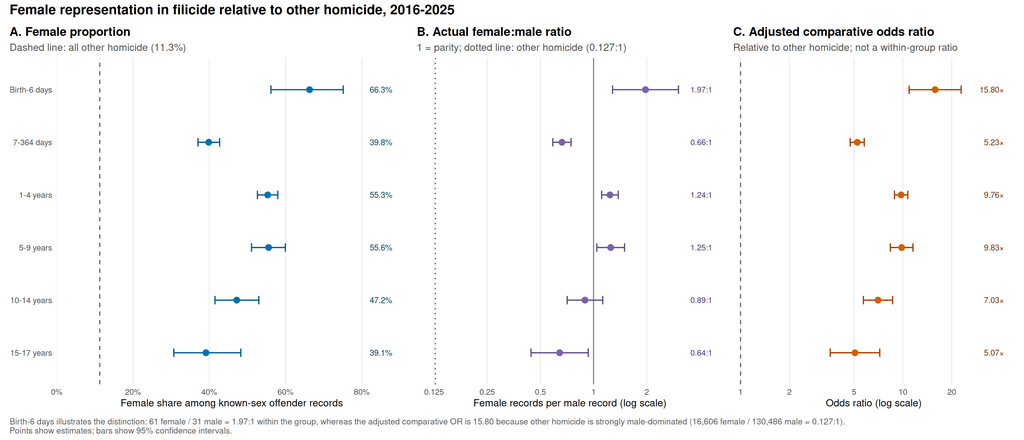

### Reporting-period sensitivity

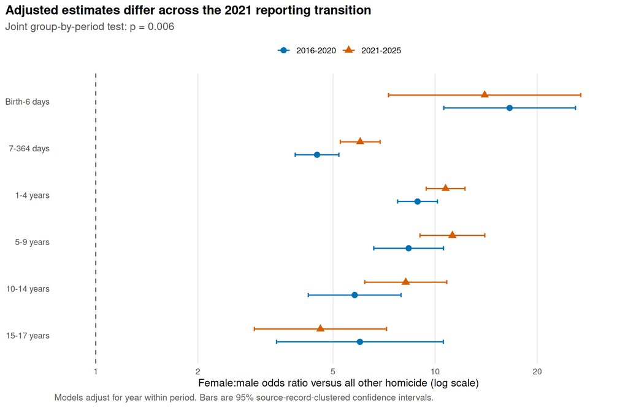

### Annual female proportions

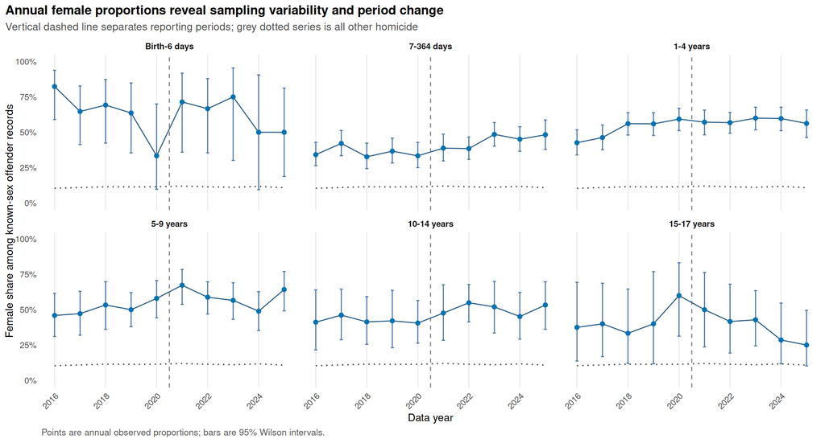

### Unknown-sex records

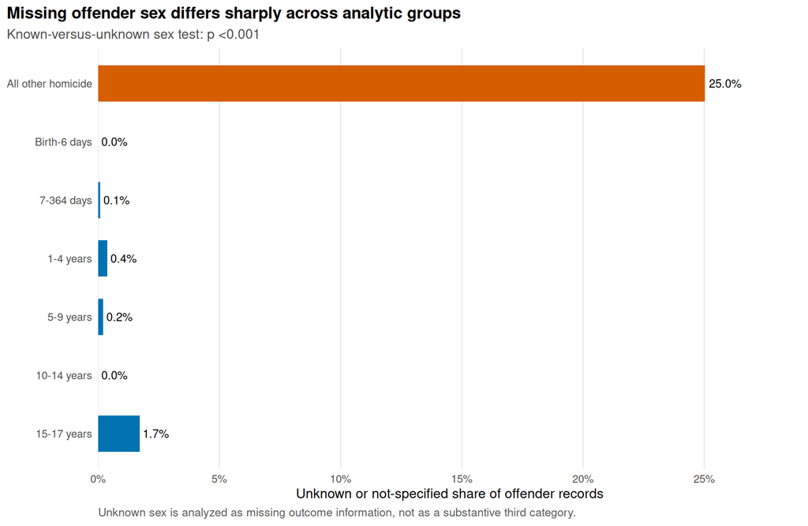

### Why the denominator changes the conclusion

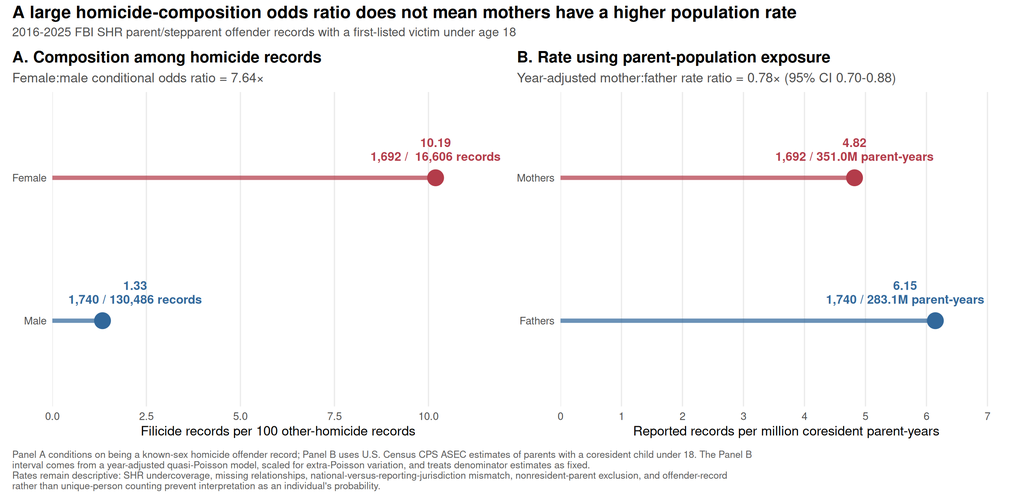

### Variant A: one-thousand-record dot grids

This unit-chart version makes the conditional homicide-record comparison concrete. Each grid represents 1,000 known-sex homicide offender records, not 1,000 women or men in the population.

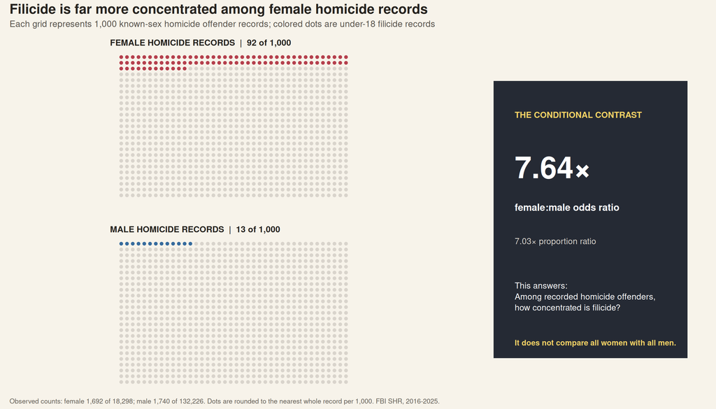

### Variant B: denominator-switch editorial graphic

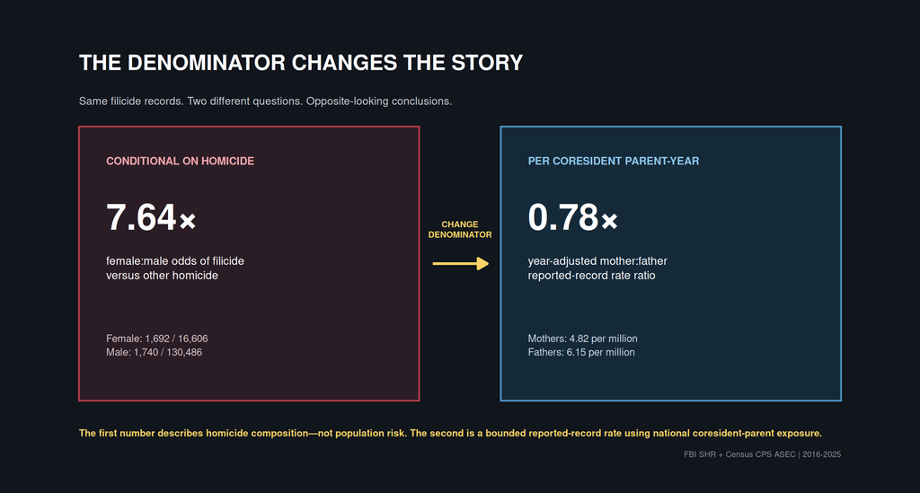

### Variant C: annual population-rate dumbbell

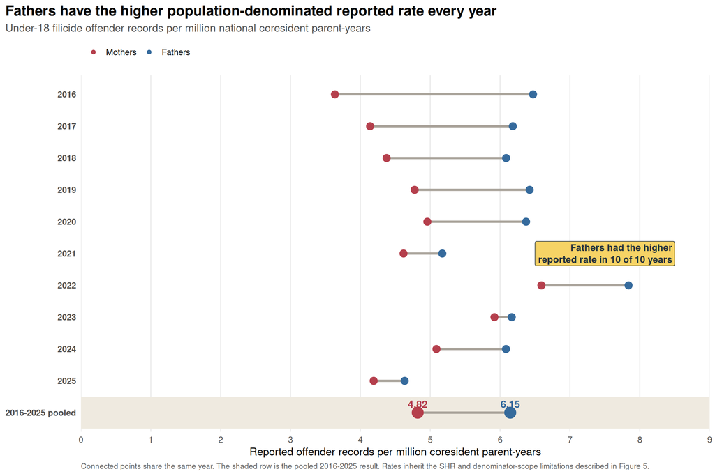

### Headline social figure

[figure not shown]

### Rate-wall headline figure

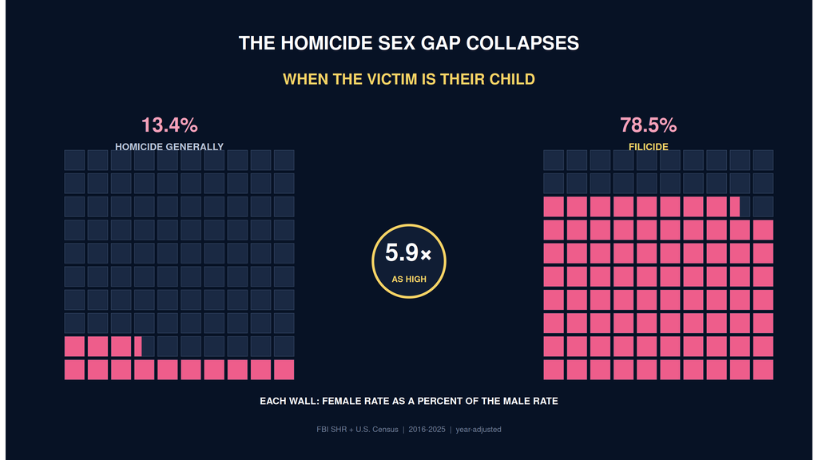